# Connecting R to imdb SQL database

The pupose of this project is to answer a series of questions and run some analysis of imdb.com’s database using SQL code.A schema of the database is presented below. All the information presented is as of November 2015.

# To do - Questions 7

Installing the required packages for this project and database. Now we can get started!

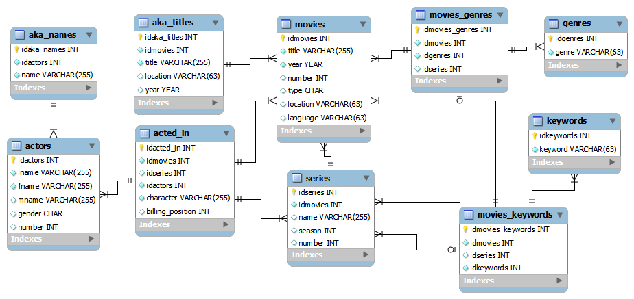

Flowchart of the Database

# Questions

How many actors are there in the database? How many movies?

```r
numactors = as.integer(dbGetQuery(db, 'SELECT COUNT(idactors) FROM actors;'))
nummovies = as.integer(dbGetQuery(db, 'SELECT COUNT(idmovies) FROM movies;'))
numactors
```

```
## [1] 3500167
```

```r
nummovies
```

```
## [1] 1298737
```

What time period does the database cover?

```r
years = dbGetQuery(db, 'SELECT DISTINCT year FROM movies;')
sort(years$year)
```

```
##   [1]    1    2    3    4    5    6    7    8    9   10   11   12   13   14
##  [15]   15   16   17   18   19   20   21   23   24   25   27   30   32   35
##  [29]   39   40   43   45   48   53   60   70  100  101  206  216  500  718
##  [43] 1585 1640 1725 1776 1809 1811 1816 1827 1830 1865 1867 1870 1873 1874
##  [57] 1878 1881 1883 1887 1888 1889 1890 1891 1892 1893 1894 1895 1896 1897
##  [71] 1898 1899 1900 1901 1902 1903 1904 1905 1906 1907 1908 1909 1910 1911
##  [85] 1912 1913 1914 1915 1916 1917 1918 1919 1920 1921 1922 1923 1924 1925
##  [99] 1926 1927 1928 1929 1930 1931 1932 1933 1934 1935 1936 1937 1938 1939
## [113] 1940 1941 1942 1943 1944 1945 1946 1947 1948 1949 1950 1951 1952 1953
## [127] 1954 1955 1956 1957 1958 1959 1960 1961 1962 1963 1964 1965 1966 1967
## [141] 1968 1969 1970 1971 1972 1973 1974 1975 1976 1977 1978 1979 1980 1981
## [155] 1982 1983 1984 1985 1986 1987 1988 1989 1990 1991 1992 1993 1994 1995
## [169] 1996 1997 1998 1999 2000 2001 2002 2003 2004 2005 2006 2007 2008 2009
## [183] 2010 2011 2012 2013 2014 2015 2016 2017 2018 2019 2020 2021 2022 2023
## [197] 2024 2025
```

Since the first film cameras were invented in 1891, we can safely conclude that anything listed as having a release date before 1891 as inaccurate. From this, we can find the range of movies that the database covers that dont include obviously incorrect years

```r
dbGetQuery(db, 'SELECT MAX(year) FROM movies;')
```

```
##   MAX(year)
## 1      2025
```

The range of movies presented lie between 1891 and 2025 (unreleased titles)

What proportion of the actors are female? male?

```r
femaleactors = dbGetQuery(db, 'SELECT * FROM actors WHERE gender IS NULL;')
nrow(femaleactors)/numactors
```

```
## [1] 0.3537034
```

```r
maleactors = dbGetQuery(db, 'SELECT * FROM actors WHERE gender = "1";')
nrow(maleactors)/ numactors
```

```
## [1] 0.6462966
```

What proportion of the entries in the movies table are actual movies and what proportion are television series, etc.?

```r
#type 1 is adult entertainment
#type 2 is video games
#type 3 is movies
#type 'NULL' is series

dbGetQuery(db, 'SELECT DISTINCT type FROM movies;')
```

```
##   type
## 1    3
## 2   NA
## 3    1
## 4    2
```

```r
dbGetQuery(db, 'SELECT * FROM movies WHERE type IS NULL LIMIT 25')
```

```
##    idmovies                                      title year type number
## 1        12                   This American Life Live! 2012   NA     NA
## 2        33                            Tweeduizendseks 2010   NA     NA
## 3        35                    Il barbiere di Siviglia 1992   NA     NA
## 4        54                      Meus Prmios Nick 2012 2012   NA     NA
## 5        76                      2nd Annual BET Awards 2002   NA     NA
## 6        78                      3rd Annual BET Awards 2003   NA     NA
## 7        79                      4th Annual BET Awards 2004   NA     NA
## 8        80                            BET Awards 2006 2006   NA     NA
## 9        81       Nickelodeon Kids' Choice Awards 2000 2000   NA     NA
## 10       82    The 16th Annual Soul Train Music Awards 2002   NA     NA
## 11       83    The 17th Annual Soul Train Music Awards 2003   NA     NA
## 12       84                The Teen Choice Awards 2001 2001   NA     NA
## 13      135        50 Most Awesomely Bad Songs... Ever 2004   NA     NA
## 14      165                 2006 American Music Awards 2006   NA     NA
```

[output cut: 37 more lines]

```r
dbGetQuery(db, 'SELECT * FROM movies WHERE type = "3" LIMIT 25')
```

```
##    idmovies                                          title year type
## 1         1                            Night of the Demons 2009    3
## 2         2 The Bad Lieutenant: Port of Call - New Orleans 2009    3
## 3         3                                 Please Like Me 2013    3
## 4         4                         A Woman of Distinction 1950    3
## 5         5                               Around the World 1943    3
## 6         6                                Chain Lightning 1950    3
## 7         7                                O-Kay for Sound 1937    3
## 8         8                                        Cabaret 1936    3
## 9         9                                Four Star Revue 1950    3
## 10       10                                     Music-Hall 1949    3
## 11       11                                        Variety 1936    3
## 12       13                                         Mmesis 2012    3
## 13       14                                   Supernatural 2005    3
## 14       15                                  El hormiguero 2006    3
```

[output cut: 37 more lines]

```r
as.integer(dbGetQuery(db, 'SELECT COUNT(*) FROM movies WHERE type = "1" '))/nummovies
```

```
## [1] 0.113488
```

```r
as.integer(dbGetQuery(db, 'SELECT COUNT(*) FROM movies WHERE type = "2" '))/nummovies
```

```
## [1] 0.01184535
```

```r
as.integer(dbGetQuery(db, 'SELECT COUNT(*) FROM movies WHERE type = "3" '))/nummovies
```

```
## [1] 0.7813322
```

```r
as.integer(dbGetQuery(db, 'SELECT COUNT(*) FROM movies WHERE type IS NULL '))/nummovies
```

```
## [1] 0.09333452
```

How many genres are there? What are their names/descriptions?

```r
dbGetQuery(db, 'SELECT DISTINCT COUNT(genre) FROM genres;')
```

```
##   COUNT(genre)
## 1           32
```

```r
genres = dbGetQuery(db, 'SELECT DISTINCT genre FROM genres;')
genres
```

```
##           genre
## 1   Documentary
## 2       Reality
## 3        Horror
## 4         Drama
## 5        Comedy
## 6       Musical
## 7          Talk
## 8       Mystery
## 9          News
## 10        Sport
## 11          Sci
## 12      Romance
## 13       Family
## 14        Short
```

[output cut: 18 more lines]

List the 10 most common genres of movies, showing the number of movies in each of these genres.

```r
moviegenres = dbGetQuery(db, "SELECT idmovies_genres, idgenres, idmovies FROM movies_genres")
#creates table showing movie ids and genre ids

genres = dbGetQuery(db, "SELECT * FROM genres INNER JOIN movies_genres ON genres.idgenres=movies_genres.idgenres")
#this joins genres and movies_genres showing the genre name next to the id

#sorts genres but number of entries
sort(table(genres$genre), decreasing = TRUE)[1:10]
```

```
##
##      Comedy       Drama Documentary     Reality      Family        Talk
##       28152       20149       14934       10360        8915        7949
##   Animation       Music     Romance        Game
##        6797        5222        4679        4367
```

Has the number of movies in each genre changed over time? Plot the overall number of movies in each year over time, and for each genre.

```r
yeargenre = dbGetQuery(db, 'SELECT COUNT(movies.idmovies) AS count, year, genre
           FROM genres, movies_genres, movies
           WHERE genres.idgenres = movies_genres.idgenres
           AND movies_genres.idmovies = movies.idmovies GROUP BY genre, year')
dbGetQuery(db, 'SELECT genre, year, COUNT(movies.idmovies)
           FROM genres, movies_genres, movies
           WHERE genres.idgenres = movies_genres.idgenres
           AND movies_genres.idmovies = movies.idmovies GROUP BY genre, year LIMIT 10')
```

```
##     genre year COUNT(movies.idmovies)
## 1  Action   NA                     48
## 2  Action 1949                      2
## 3  Action 1950                      3
## 4  Action 1951                      2
## 5  Action 1952                      4
## 6  Action 1953                      3
## 7  Action 1954                      2
## 8  Action 1955                      5
## 9  Action 1956                      1
## 10 Action 1957                      5
```

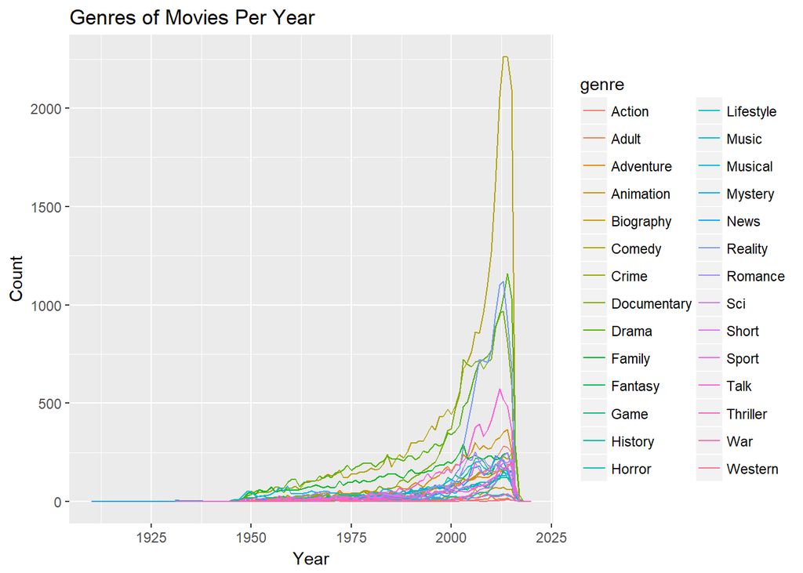

```r
ordermovies = order(yeargenre$year)
yeargenre = yeargenre[ordermovies,]
yeargenre = na.omit(yeargenre) #remove NA observations
library(ggplot2)
ggplot(yeargenre, aes(year, count, colour = genre)) +geom_line() +xlab("Year") + ylab("Count") + ggtitle("Genres of Movies Per Year")
```

Who are the actors that have been in the most movies? List the top 20.

```r
counts = dbGetQuery(db, 'SELECT fname, lname, count FROM counts')
actorcounts = order(counts$count, decreasing = TRUE)
counts = counts[actorcounts,]
head(counts, n = 20)
```

```
##                      fname      lname count
## 3284300               Alex     Trebek  7259
## 1963707             Johnny    Gilbert  7233
## 1363104                Bob     Barker  6898
## 3007713                Pat      Sajak  6278
## 1191283              Vanna      White  6219
## 1164868              Carol  Vorderman  5740
## 863139              Janice Pennington  5540
## 2401654                Jay       Leno  5352
## 2745293             Johnny      Olson  4971
## 2407134              David  Letterman  4740
## 3413195            Richard   Whiteley  4605
## 2727246 O'Donnell, Charlie       <NA>  4389
## 3400314              Frank     Welker  4272
## 3079123               Paul    Shaffer  4215
## 2724636     O'Brien, Conan       <NA>  4040
## 2955611                Rod      Roddy  4013
## 509347              Helena     Isabel  3994
## 1832364                Lus Esparteiro  3914
## 1569248             Manuel     Cavaco  3803
## 614277     Katherine Kelly       Lang  3759
```

Who are the 10 actors that performed in the most movies within any given year? What are their names and the year they starred in these movies?

```r
dbGetQuery(db, 'CREATE TEMP TABLE num11 AS
           SELECT fname, lname, COUNT(acted_in.idactors) AS count, year
           FROM acted_in, actors, movies
           WHERE acted_in.idactors = actors.idactors
           AND movies.idmovies = acted_in.idmovies
           AND movies.type = 1
           GROUP BY year, acted_in.idactors')
```

```
## data frame with 0 columns and 0 rows
```

```r
allactorsbyyear = dbGetQuery(db, 'SELECT DISTINCT * FROM num11
                 WHERE year > "1878"
                 ORDER BY count DESC')

top10byyear = dbGetQuery(db, 'SELECT DISTINCT * FROM num11
                 WHERE year > "1878"
                 ORDER BY count DESC
                 LIMIT 10')
top10byyear
```

```
##    fname    lname count year
## 1  Marco Banderas   229 2007
## 2    Lee    Stone   214 2003
## 3    Lee    Stone   208 2005
## 4    Lee    Stone   201 2004
## 5   Alex  Sanders   192 1995
## 6   Alex  Sanders   186 1994
## 7  Talon     <NA>   184 2005
## 8  James     Deen   178 2008
## 9  James     Deen   178 2009
## 10 Marco Banderas   175 2006
```

Who are the 10 actors that have the most aliases? (i.e., see the aka_names table)

```r
#SQL query lists out actors and number of aliases in order
dbGetQuery(db, 'SELECT fname, lname, count(aka_names.idactors) AS count
           FROM aka_names, actors
           WHERE aka_names.idactors = actors.idactors
           GROUP BY aka_names.idactors ORDER BY count DESC LIMIT 10')
```

```
##           fname    lname count
## 1          Jess   Franco    76
## 2  D'Amato, Joe     <NA>    69
## 3         Uschi   Digard    60
## 4      Herschel   Savage    52
## 5       Godfrey       Ho    49
## 6          Joey  Silvera    41
## 7        Zuzana  Presova    37
## 8     Christoph    Clark    37
## 9     Nathanael      Len    37
## 10       Sandra Kalerman    36
```